# Data Cleaning

## Data Cleaning :

- Data cleaning means fixing bad data in your data set.
- Data cleaning is the process of fixing or removing incorrect, corrupted, incorrectly formatted, duplicate, or incomplete data within a dataset. When combining multiple data sources, there are many opportunities for data to be duplicated or mislabeled.
- Having clean data will ultimately increase overall productivity and allow for the highest quality information in your decision-making.
- Bad data could be:

  ```
    1. Wrong data.
    2. Data in wrong format.
    3. Duplicates.
    4. Empty cells / Missing values.
    5. Outliers.
  ```

## 1. Wrong data :

- "Wrong data" does not have to be "empty cells" or "wrong format", it can just be wrong, like if someone registered 500 instead of 50 years in "Age" column.
- There are 2 options to handle with this wrong data, they are :

  ```
      Option - 1 : Replace - One way to fix wrong values is to replace them with something else.
      Option - 2 : Remove  - Another way of handling wrong data is to remove the rows that contains wrong data.
  ```

**Here we are going to create our own data-set with two columns as "Age" and "Gender" variables, dataframe name as "df1".**

```python
# import numpy as np
import numpy as np

# import pandas as pd
import pandas as pd

# Create the "df1" dataframe with two columns as "Age" and "Gender" variables.
df1 = pd.DataFrame({"Age":[15, 20, 18, 40, 500],
                    "Gender":["Male", "Female", "Female", "Female", "Male"]})

# Print the dataframe.
df1
```

|  | Age | Gender |
| --- | --- | --- |
| 0 | 15 | Male |
| 1 | 20 | Female |
| 2 | 18 | Female |
| 3 | 40 | Female |
| 4 | 500 | Male |

- If we take a look at our data set, we can see that in row 5, the Age is 500, but for all the other rows the Age is between 1 to 100 years. we conclude with the fact that this person did not live 500 years.
- Sometimes we can spot wrong data by looking at the data set, because we have an expectation of what it should be. But if data set having more records then we are unable to see manually. Here we need to apply conditions to a perticular columns, to find the wrong data.
- Here below we are applying condition to check the Age column data set, whether column having wrong data or not.

```python
# Checking Age column data set, whether column having wrong data or not.

# Using for loop to check the wrong data set index number and values.
for x in df1.index:

    # Display if Age is less than "1" years or greater than "100" years.
    if df1.loc[x, "Age"] < 1 or df1.loc[x, "Age"] > 100:

        # print the wrong data set index name and value.
        # If Age column doen't contains wrong data set, then it will not print.
        print("Index Name is : {} and value={}".format(x, df1.iloc[x][0]))
```

```
Index Name is : 4 and value=500
```

- In the above example, we can see that in Index=4 and value=500 is contains wrong data. So we conclude with the fact that this person did not live 500 years.
- In the above example, we have used index, i.e. index property returns the index information of the DataFrame.
- There are 2 options to handle with this wrong data, we will go through one by one.

#### Option - 1 : Replace - One way to fix wrong values is to replace them with something else.

- In our example, it is most likely a typo, and the value should be "50" instead of "500", and we could just insert "50" in row 5 (Index=4 and value=500).

```python
# Replace "Age"=500 to 50 and store it in original dataframe.
df1["Age"].replace(500, 50, inplace=True)

# Print the dataframe.
df1
```

|  | Age | Gender |
| --- | --- | --- |
| 0 | 15 | Male |
| 1 | 20 | Female |
| 2 | 18 | Female |
| 3 | 40 | Female |
| 4 | 50 | Male |

- In the above example, we have repleced wrong data Age=500 to 50 years and store it in original dataframe.
- For small data sets you might be able to replace the wrong data one by one, but not for big data sets.
- To replace wrong data for larger data sets we need to create some rules.

#### Option - 2 : Remove - Another way of handling wrong data is to remove the rows that contains wrong data.

- This way you do not have to find out what to replace them with, and there is a good chance you do not need them to do your analyses.

**Here we are going with "df1" dataframe with same wrong data set.**

```python
# import numpy as np
import numpy as np

# import pandas as pd
import pandas as pd

# Create the "df1" dataframe with two columns as "Age" and "Gender" variables.
df1 = pd.DataFrame({"Age":[15, 20, 18, 40, 500],
                    "Gender":["Male", "Female", "Female", "Female", "Male"]})

# Print the dataframe.
df1
```

|  | Age | Gender |
| --- | --- | --- |
| 0 | 15 | Male |
| 1 | 20 | Female |
| 2 | 18 | Female |
| 3 | 40 | Female |
| 4 | 500 | Male |

- If we take a look at our data set, we can see that in row 5, the Age is 500, but for all the other rows the Age is between 1 to 100 years. we conclude with the fact that this person did not live 500 years.
- So we do not have to find out what to replace them with, so we are going to remove that perticular record from the dataset.

```python
# Delete rows where "Age" is less than "1" years or greater than "100" years.

# Using for loop to iterate with each element.
for x in df1.index:

    # If Age is less than "1" years or greater than "100" years.
    if df1.loc[x, "Age"] < 1 or df1.loc[x, "Age"] > 100:

        # Drop the those wrong data's and store it in original dataframe.
        df1.drop(x, inplace = True)

# Print the dataframe.
print(df1)
```

```
   Age  Gender
0   15    Male
1   20  Female
2   18  Female
3   40  Female
```

- In the above example, we have removed wrong data which contains Age=500 years and store it in original dataframe.
- In real senario's we never recommende to go through with option - 2, because here we are going to remove the wrong data, so we will loss the data.
- To handle with wrong data, we will recommended to go through this option-1.

## 2. Data in wrong format :

- Cells with data of wrong format can make it difficult, or even impossible, to analyze data.
- To fix it, we need to convert all cells in the columns into the same format (Datatype).

#### Convert all cells in the columns into the same format (Datatype).

- Here we are going to create our own data-set with two columns as "Age" and "Gender" variables, dataframe name as "df2".

```python
# import numpy as np
import numpy as np

# import pandas as pd
import pandas as pd

# Create the "df2" dataframe with two columns as "Age" and "Gender" variables.
df2 = pd.DataFrame({"Age":[15, 20, 18, 40, "20"],
                    "Gender":["Male", "Female", "Female", "Female", "Male"]})

# Print the dataframe.
df2
```

|  | Age | Gender |
| --- | --- | --- |
| 0 | 15 | Male |
| 1 | 20 | Female |
| 2 | 18 | Female |
| 3 | 40 | Female |
| 4 | 20 | Male |

```python
# print the information of "df2" dataframe by using info().
df2.info()
```

```
<class 'pandas.core.frame.DataFrame'>
RangeIndex: 5 entries, 0 to 4
Data columns (total 2 columns):
 #   Column  Non-Null Count  Dtype
---  ------  --------------  -----
 0   Age     5 non-null      object
 1   Gender  5 non-null      object
dtypes: object(2)
memory usage: 208.0+ bytes
```

- In our Data Frame, we have one cell with the wrong format. Check out row 5 , the 'Age' column should be a int that represents a Age. As per our requirement Age column Dtype should be int, but here its showing object.
- Let's try to convert all cells in the 'Age' column into int.
- Pandas has a astype() method for this :

```python
# Convert all cells in the "Age" column into the int Dtype by using astype() method.
df2["Age"] = df2["Age"].astype("int")

# Print the dataframe.
df2
```

|  | Age | Gender |
| --- | --- | --- |
| 0 | 15 | Male |
| 1 | 20 | Female |
| 2 | 18 | Female |
| 3 | 40 | Female |
| 4 | 20 | Male |

- Now once again we are going to check the Dtype of the all columns.

```python
# print the information of "df2" dataframe by using info().
df2.info()
```

```
<class 'pandas.core.frame.DataFrame'>
RangeIndex: 5 entries, 0 to 4
Data columns (total 2 columns):
 #   Column  Non-Null Count  Dtype
---  ------  --------------  -----
 0   Age     5 non-null      int32
 1   Gender  5 non-null      object
dtypes: int32(1), object(1)
memory usage: 188.0+ bytes
```

- As you can see from the result, the Age column Dtype has been converted to int32.

## 3. Duplicates :

- Duplicate rows are rows that have been registered more than one time.
- To fix it, we need to remove the duplicate records.

**Here we are going to create our own data-set with two columns as "Age" and "Gender" variables, dataframe name as "df3".**

```python
# import numpy as np
import numpy as np

# import pandas as pd
import pandas as pd

# Create the "df3" dataframe with two columns as "Age" and "Gender" variables.
df3 = pd.DataFrame({"Age":[15, 18, 18, 40, 45],
                    "Gender":["Male", "Female", "Female", "Female", "Male"]})

# Print the dataframe.
df3
```

|  | Age | Gender |
| --- | --- | --- |
| 0 | 15 | Male |
| 1 | 18 | Female |
| 2 | 18 | Female |
| 3 | 40 | Female |
| 4 | 45 | Male |

- By taking a look at our "df3" data set, we can assume that row 2 and 3 are duplicates.
- To discover duplicates, we can use the duplicated() method.
- The duplicated() method returns a Boolean values for each row.
- Returns True for every row that is a duplicate, othwerwise False

```python
# Check the duplicated recoreds.
df3.duplicated()
```

```
0    False
1    False
2     True
3    False
4    False
dtype: bool
```

- In the above example, we can see that row 3 returns True, so here row 3 is duplicate record. We are going to remove the duplicate records from the "df3" dataframe.

```python
# Remove the duplicates from "df3" by using drop_duplicates() method.
df3.drop_duplicates(inplace=True, ignore_index=True)

# Print the dataframe.
df3
```

|  | Age | Gender |
| --- | --- | --- |
| 0 | 15 | Male |
| 1 | 18 | Female |
| 2 | 40 | Female |
| 3 | 45 | Male |

- In the above example, we have removed duplicate recoreds. We have used inplace=True, it will make sure that the method does not return a new DataFrame, it's stored in the original DataFrame. Ans also we have used ignore_index=True, it will reset the index numbers.

## 4. Empty cells / Missing values :

- Empty cells / Missing values can potentially give you a wrong result when you analyze data.
- There are 2 options to handle with Empty cells / Missing values, they are :

  ```
      Option - 1 : Remove Rows.
      Option - 2 : Replace Empty Values.
  ```

**Here we are going to create our own data-set with two columns as "Age" and "Gender" variables, dataframe name as "df4".**

```python
# import numpy as np
import numpy as np

# import pandas as pd
import pandas as pd

# Create the "df4" dataframe with two columns as "Age" and "Gender" variables.
df4 = pd.DataFrame({"Age":[15, np.nan, 19, 46, 45],
                    "Gender":["Male", "Female", "Female", "Female", np.nan]})

# Print the dataframe.
df4
```

|  | Age | Gender |
| --- | --- | --- |
| 0 | 15.0 | Male |
| 1 | NaN | Female |
| 2 | 19.0 | Female |
| 3 | 46.0 | Female |
| 4 | 45.0 | NaN |

```python
# Check the missing values records.
df4.isnull()
```

|  | Age | Gender |
| --- | --- | --- |
| 0 | False | False |
| 1 | True | False |
| 2 | False | False |
| 3 | False | False |
| 4 | False | True |

- The isnull() method returns a DataFrame object where all the values are replaced with a Boolean value True for NULL values, and otherwise False.
- It will give the exact positions where NaN values are present.

```python
# Check the total number of missing values present in the each column.
df4.isnull().sum()
```

```
Age       1
Gender    1
dtype: int64
```

- The isnull().sum() method returns he total number of missing values (count) present in the each column.

```python
# Check the total missing values & there percentage for each variables.

# Check the total number of missing values present in the each variables.
x = df4.isnull().sum()

# Check the percentage of the missing values for each variables.
y = (df4.isnull().sum() / len(df4))*100

# store the total missing values & there percentage in "z".
z = {"Number of missing values":x, "Percentage of missing values":y}

# Create a new DataFrame as "missing".
# Pass the "z" object to "missing" DataFrame.
# Set the column labels.
missing = pd.DataFrame(z, columns=["Number of missing values", "Percentage of missing values"])

# Print the "missing" DataFrame.
missing
```

|  | Number of missing values | Percentage of missing values |
| --- | --- | --- |
| Age | 1 | 20.0 |
| Gender | 1 | 20.0 |

- In the above example, we got total missing values & there percentage for each variables.

```python
# Sort the missing values based on there percentages.
missing.sort_values(by="Percentage of missing values", ascending=True)
```

|  | Number of missing values | Percentage of missing values |
| --- | --- | --- |
| Age | 1 | 20.0 |
| Gender | 1 | 20.0 |

- In the above example, we have sorted in ascending order based on there Percentage of missing values.
- We are going to fix the missing values from the "df4" DataFrame. There are 2 options to handle with Empty cells / Missing values.
- Here we are looking with option - 1.

#### Option - 1 : Remove Rows :

- One way to deal with empty cells is to remove rows that contain empty cells.

```python
''' Remove the rows from "df4" DataFrame that contains missing values and return
    a new Data Frame with no empty cells by usnig dropna() method.'''
df5 = df4.dropna()

# Print the new DataFrame.
df5
```

|  | Age | Gender |
| --- | --- | --- |
| 0 | 15.0 | Male |
| 2 | 19.0 | Female |
| 3 | 46.0 | Female |

- In the above example, we have removed empty / missing records from the "df4" DataFrame and returns a new Data Frame as "df5" with no empty cells.
- If data sets are very big then this is usually OK to removing a few rows will not have a big impact on the result.
- If data sets are small then this is usually not OK to removing a few rows will have a big impact on the result. So for empty cells / missing values we will recommende to replace Empty Values.

#### Option - 2 : Replace Empty Values :

- Another way of dealing with empty cells is to insert a new value instead.
- This way you do not have to delete entire rows just because of some empty cells.
- The fillna() method allows us to replace empty cells with a value.
- Replace Empty Values :

  ```
    - Fill with some specified value.
    - Continous Variables - Replace with eithe Mean or Median value.
    - Discrete Variables - Replace with Mode value.
  ```

**Here we are going to create our own data-set with two columns as "Age" and "Gender" variables, dataframe name as "df6".**

```python
# import numpy as np
import numpy as np

# import pandas as pd
import pandas as pd

# Create the "df6" dataframe with two columns as "Age" and "Gender" variables.
df6 = pd.DataFrame({"Age":[15, np.nan, 19, 46, 45],
                    "Gender":[np.nan, "Female", "Female", "Female", "Male"]})

# Print the dataframe.
df6
```

|  | Age | Gender |
| --- | --- | --- |
| 0 | 15.0 | NaN |
| 1 | NaN | Female |
| 2 | 19.0 | Female |
| 3 | 46.0 | Female |
| 4 | 45.0 | Male |

```python
# Replacing the missing values from "Age" variable with value of 0 by using replce().
df6["Age"].replace(np.nan, 0, inplace=True)

# Print the dataframe.
df6
```

|  | Age | Gender |
| --- | --- | --- |
| 0 | 15.0 | NaN |
| 1 | 0.0 | Female |
| 2 | 19.0 | Female |
| 3 | 46.0 | Female |
| 4 | 45.0 | Male |

- In the above example, we have replaced the missing values from "Age" variable with value of 0 by using replace() method.

```python
# Replacing the missing values from "Gender" variable with Mode value by using fillna().

# Calculate the Mode from "Gender" variable and store it in "x" object.
x = df6["Gender"].mode()[0]

# Replace the missing values from "Gender" variable with Mode value by using fillna()
df6["Gender"].fillna(x, inplace=True)

# Print the dataframe.
df6
```

|  | Age | Gender |
| --- | --- | --- |
| 0 | 15.0 | Female |
| 1 | 0.0 | Female |
| 2 | 19.0 | Female |
| 3 | 46.0 | Female |
| 4 | 45.0 | Male |

- In the above example, we have replaced the missing values from "Gender" variable with Mode value by using fillna() method. Here mode value is "Female".
- Here we have used mode()[0] : the value that appears first most frequently.

**Here we are going to create our own data-set with two columns as "Age" and "Gender" variables, dataframe name as "df7".**

```python
# import numpy as np
import numpy as np

# import pandas as pd
import pandas as pd

# Create the "df7" dataframe with two columns as "Age" and "Gender" variables.
df7 = pd.DataFrame({"Age":[15, np.nan, 19, 46, 45],
                    "Gender":["Male", "Female", "Female", "Female", "Male"]})

# Print the dataframe.
df7
```

|  | Age | Gender |
| --- | --- | --- |
| 0 | 15.0 | Male |
| 1 | NaN | Female |
| 2 | 19.0 | Female |
| 3 | 46.0 | Female |
| 4 | 45.0 | Male |

- By taking a look at our DataFrame, we can assume that, in "Age" variable row 2 is missing value.

```python
# Replacing the missing values from "Age" variable with Mean value by using fillna().

# Calculate the Mean from "Age" variable and store it in "x" object.
x = df7["Age"].mean()

# Replace the missing values from "Age" variable with Mean value by using fillna().
df7["Age"].fillna(x, inplace=True)

# Print the dataframe.
df7
```

|  | Age | Gender |
| --- | --- | --- |
| 0 | 15.00 | Male |
| 1 | 31.25 | Female |
| 2 | 19.00 | Female |
| 3 | 46.00 | Female |
| 4 | 45.00 | Male |

- In the above example, we have replaced the missing values from "Age" variable with Mean value by using fillna() method. Here mean value is 31.25
- Here Mean is the average value (the sum of all values divided by number of values).
- If there are no outliers, then only we will go with mean option. Because outliers are heavily effects the mean value.
- If there are outliers, then we will go with median option. Because outliers are heavily effects the mean value and lesser effects to median as compare to mean value.

**Here we are going to create our own data-set with two columns as "Age" and "Gender" variables, dataframe name as "df8".**

```python
# import numpy as np
import numpy as np

# import pandas as pd
import pandas as pd

# Create the "df8" dataframe with two columns as "Age" and "Gender" variables.
df8 = pd.DataFrame({"Age":[15, np.nan, 19, 46, np.nan],
                    "Gender":["Male", "Female", "Female", "Female", "Male"]})

# Print the dataframe.
df8
```

|  | Age | Gender |
| --- | --- | --- |
| 0 | 15.0 | Male |
| 1 | NaN | Female |
| 2 | 19.0 | Female |
| 3 | 46.0 | Female |
| 4 | NaN | Male |

- By taking a look at our DataFrame, we can assume that, in "Age" variable row 2 and 5 are missing values.

```python
# Replacing the missing values from "Age" variable with Median value by using fillna().

# Calculate the Mean from "Age" variable and store it in "x" object.
x = df8["Age"].median()

# Replace the missing values from "Age" variable with Median value by using fillna().
df8["Age"].fillna(x, inplace=True)

# Print the dataframe.
df8
```

|  | Age | Gender |
| --- | --- | --- |
| 0 | 15.0 | Male |
| 1 | 19.0 | Female |
| 2 | 19.0 | Female |
| 3 | 46.0 | Female |
| 4 | 19.0 | Male |

- In the above example, we have replaced the missing values from "Age" variable with Median value by using fillna() method. Here median value is 19.0
- Here Median is the value in the middle, after you have sorted all values ascending.

#### We can replace the missing values by using SimpleImputer() by using sklearn library.

- Now here we are going to create our own data-set with two columns as "Age" and "Gender" variables, dataframe name as "df9".

```python
# import numpy as np
import numpy as np

# import pandas as pd
import pandas as pd

# Create the "df9" dataframe with two columns as "Age" and "Gender" variables.
df9 = pd.DataFrame({"Age":[15, 25, np.nan, 46, 34, 26],
                    "Gender":["Male", np.nan, "Female", "Female", "Male", "Male"]})

# Print the dataframe.
df9
```

|  | Age | Gender |
| --- | --- | --- |
| 0 | 15.0 | Male |
| 1 | 25.0 | NaN |
| 2 | NaN | Female |
| 3 | 46.0 | Female |
| 4 | 34.0 | Male |
| 5 | 26.0 | Male |

- By taking a look at our DataFrame, we can assume that, in "Age" variable row 3 is missing value and in "Gender" variable row 2 is missing value.
- Now below we are going to fix the these missing values.

```python
# Replacing the missing values from "Age" variable with Mean value by using SimpleImputer().

# importing SimpleImputer from sklearn.impute library.
from sklearn.impute import SimpleImputer

# Set the mean formula and store it in "mean_imputer" object.
mean_imputer = SimpleImputer(strategy="mean")

# Replace the missing values from "Age" variable with Mean value by using SimpleImputer().
# Pass the "mean_imputer" object.
df9["Age"] = mean_imputer.fit_transform(df9[["Age"]])

# Print the dataframe.
df9
```

|  | Age | Gender |
| --- | --- | --- |
| 0 | 15.0 | Male |
| 1 | 25.0 | NaN |
| 2 | 29.2 | Female |
| 3 | 46.0 | Female |
| 4 | 34.0 | Male |
| 5 | 26.0 | Male |

- In the above example, we have replaced the missing values from "Age" variable with Mean value by using SimpleImputer() method. Here mean value is 29.2
- Here Mean is the average value (the sum of all values divided by number of values).
- Here SimpleImputer is a class in the sklearn. impute module that can be used to replace missing values in a dataset, using a variety of input strategies.
- Here fit_transform() method : The fit(data) method is used to compute the mean and std dev for a given feature to be used further for scaling. The transform(data) method is used to perform scaling using mean and std dev calculated using the . fit() method.

```python
'''Replacing the missing values from "Gender" variable with
   most_frequent (mode) value by using SimpleImputer().'''

# importing SimpleImputer from sklearn.impute library.
from sklearn.impute import SimpleImputer

# Set the mode formula and store it in "mode_imputer" object.
mode_imputer = SimpleImputer(strategy="most_frequent")

'''Replace the missing values from "Gender" variable with
   most_frequent (mode) value by using SimpleImputer().'''
# Pass the "mode_imputer" object.
df9["Gender"] = mode_imputer.fit_transform(df9[["Gender"]])

# Print the dataframe.
df9
```

|  | Age | Gender |
| --- | --- | --- |
| 0 | 15.0 | Male |
| 1 | 25.0 | Male |
| 2 | 29.2 | Female |
| 3 | 46.0 | Female |
| 4 | 34.0 | Male |
| 5 | 26.0 | Male |

## 5. Outliers :

- An outlier is a data point in a data set that is diatance from all other observations, which is significantly different from the remaining data.
- A data point thet lies outside the overall distribution of the dataset.

**What are the impacts of having outliers in a dataset ?**

1. It causes various problems during our statistical analysis (It amy cause a significant impact on the mean and the standard deviation). Statistics such as the mean and variance are very suspectable to outliers.
1. In addition, some machine learning models are sensitive to outliers which may decrease their performance. Thus, depending on which algorithm we wish to train, we often remove outliers from our variables.

**Reasons for Outliers ?**

1. Data Entry Errors (Ex : Entering salary as 1,00,000 instead of 10,000)
2. Measurement Errors (Ex : Measuring in meters instead of KM)
3. Instrumental Errors.

**Types of Outliers ?**

1. Univariate Outliers ----> Identifying Outliers for single variable.
2. Bivariate Outliers ----> Identifying Outliers by analyzing 2 variables at a time.

**There are 3 options (3R Technique) to handle with this Outliers, they are :**

1. Remove (remove the outliers from our dataset).
1. Replace the outliers :
   - Rectify or Replace ---> (Data Entry Errors) ---> Ask and confirm it from the Data Engineering Team.
   - Replace with Upper limit & Lower limit based on the IQR.
1. Retain (consider for analysis) ---> Treat them seperately.

**Here we are going to create our own data-set with one column as "marks" variable, dataframe name as "df".**

```python
# import numpy as np
import numpy as np

# import pandas as pd
import pandas as pd

# Create the "df" dataframe with one variable as "marks".
df = pd.DataFrame({"marks":[10, 11, 12, 25, 25, 27, 31, 33, 34, 34, 36, 36, 43, 50, 59]})

# Print the dataframe.
df
```

|  | marks |
| --- | --- |
| 0 | 10 |
| 1 | 11 |
| 2 | 12 |
| 3 | 25 |
| 4 | 25 |
| 5 | 27 |
| 6 | 31 |
| 7 | 33 |
| 8 | 34 |
| 9 | 34 |
| 10 | 36 |
| 11 | 36 |
| 12 | 43 |
| 13 | 50 |
| 14 | 59 |

- above we have created "df" DataFrame with "marks" variable.
- Now we are going to find the Outliers. There are various ways to find the outliers, they are :

  ```
    1. Box Plot
    2. IQR
  ```

**1. Identifying outliers based on Boxplot.**

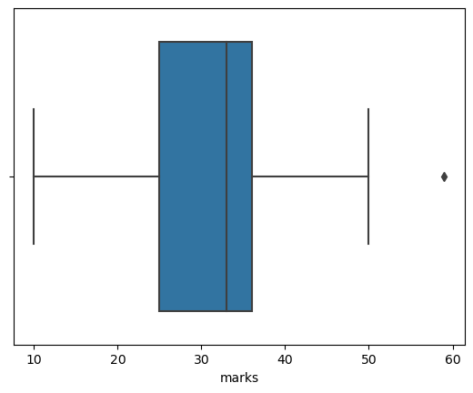

```python
# WAPP to identify the outliers based on boxplot().

# import pandas as pd
import pandas as pd

# import matplotlib as plt
import matplotlib.pyplot as plt

# import seaborn as sns
import seaborn as sns

# Draw Box Plot.
sns.boxplot(x=df["marks"])

# Print the Box Plot.
plt.show()
```

- In the above graph, can clearly see that values above 53 are acting as the outliers.
- Now we are going to find the position (index number) of the outliers from the "df" DataFrame.

```python
# Position of the Outlier
print(np.where(df['marks']>53))
```

```
(array([14], dtype=int64),)
```

**1. Identifying outliers based on IQR.**

```python
# WAPP to identify the outliers based on IQR.

# import numpy as np
import numpy as np

# import pandas as pd
import pandas as pd

# Calculate Q1 and print it.
Q1 = df["marks"].quantile(0.25)
print("Q1:",Q1)

# Calculate Q3 and print it.
Q3 = df["marks"].quantile(0.75)
print("Q3:",Q3)

# Calculate IQR and print it.
IQR = Q3 - Q1
print("IQR:",IQR)

# Calculate Lower limit of outlier and print it.
lower_limit = Q1 - (IQR * 1.5)
print("lower_limit:",lower_limit)

# Calculate Upper limit of outlier and print it.
upper_limit = Q3 + (IQR * 1.5)
print("upper_limit:",upper_limit)

# Identify the outliers based on IQR and print it.
df[(df["marks"] < lower_limit) | (df["marks"] > upper_limit)]
```

```
Q1: 25.0
Q3: 36.0
IQR: 11.0
lower_limit: 8.5
upper_limit: 52.5
```

|  | marks |
| --- | --- |
| 14 | 59 |

**Handling the Outliers with option -1 : Remove**

```python
# Removing the outliers with drop().
df.drop(index=14)
```

|  | marks |
| --- | --- |
| 0 | 10 |
| 1 | 11 |
| 2 | 12 |
| 3 | 25 |
| 4 | 25 |
| 5 | 27 |
| 6 | 31 |
| 7 | 33 |
| 8 | 34 |
| 9 | 34 |
| 10 | 36 |
| 11 | 36 |
| 12 | 43 |
| 13 | 50 |

- The above code can be used to drop a row from the dataset given the row_indexes to be dropped.
- In the above example, we can clearly see that Outliers are removed from the DataFrame.
- Here we are not going to store these changes in the original or new dataset, its only display purpose. If you want to store the changes in the original dataset, pass the inplace=True. If you want to store the changes in the new dataset then assign the new DataFrame name.

**Handling the Outliers with option -2 : Replace**

- Here we are replacing the outliers based on confirmation from the data engineer team / based on research / based on domain expertise.
- Here we are replacing the outliers by using feature_engine library, we need to install this library, we have already installed this library in this jupiter notebook.

```python
# WAPP to replace the outliers based on confirmation by using feature_engine library.

# import the feature_engine library.
from feature_engine.outliers import ArbitraryOutlierCapper

# Calling the ArbitraryOutlierCapper and stored as "capper" object.
# Pass the capping value for the right tail of the distribution.
# Pass the capping value for the left tail of the distribution.
capper = ArbitraryOutlierCapper(max_capping_dict = {"marks":52},
                                min_capping_dict = {"marks": 8})

# Print the DataFrame.
capper.fit_transform(df[["marks"]])
```

|  | marks |
| --- | --- |
| 0 | 10 |
| 1 | 11 |
| 2 | 12 |
| 3 | 25 |
| 4 | 25 |
| 5 | 27 |
| 6 | 31 |
| 7 | 33 |
| 8 | 34 |
| 9 | 34 |
| 10 | 36 |
| 11 | 36 |
| 12 | 43 |
| 13 | 50 |
| 14 | 52 |

- In the above example, we can see that outliers are replaced as upper_limit_outliers replaced with value=52 and upper_limit_outliers replaced with value=8.
- Here ArbitraryOutlierCapper() caps the maximum or minimum values of a variable at an arbitrary value indicated by the user. The user must provide the maximum or minimum values that will be used to cap each variable in a dictionary {feature:capping value}.
- Here max_capping_dict is dictionary containing the user specified capping values for the right tail of the distribution of each variable (maximum values).
- Here min_capping_dict is dictionary containing user specified capping values for the left tail of the distribution of each variable (minimum values).
- Here fit_transform() method : Fit to the data. Then transform it.

**Handling the Outliers with option -2 : Replace**

- Here we are replacing the outliers with Upper limit & Lower limit based on the IQR.

```python
# WAPP to replace the outliers based on the IQR by using feature_engine library.

# import the feature_engine library.
from feature_engine.outliers import Winsorizer

# Calling the Winsorizer and stored as "win" object.
# Pass the capping_method="iqr".
# Pass tail="both".
# Pass fold=1.5
win = Winsorizer(capping_method="iqr", tail="both", fold=1.5)

# Print the DataFrame.
win.fit_transform(df[["marks"]])
```

|  | marks |
| --- | --- |
| 0 | 10.0 |
| 1 | 11.0 |
| 2 | 12.0 |
| 3 | 25.0 |
| 4 | 25.0 |
| 5 | 27.0 |
| 6 | 31.0 |
| 7 | 33.0 |
| 8 | 34.0 |
| 9 | 34.0 |
| 10 | 36.0 |
| 11 | 36.0 |
| 12 | 43.0 |
| 13 | 50.0 |
| 14 | 52.5 |

```python
# Check the right tail and left tail values of the distribution.
print(win.left_tail_caps_, win.right_tail_caps_)
```

```
{'marks': 8.5} {'marks': 52.5}
```

- In the above example, we can see that outliers are replaced as right tail vaues replaced with 52.5 and left tail vaues replaced with 8.5
- Here the Winsorizer() caps maximum and / or minimum values of a variable. The Winsorizer() works only with numerical variables. A list of variables can be indicated. Alternatively, the Winsorizer() will select all numerical variables in the train set.
- Here capping_method='iqr' fold is the value to multiply the IQR.
- Here tail : Whether to cap outliers on the right, left or both tails of the distribution. Can take ‘left’, ‘right’ or ‘both’.
- Here fold : How far out to to place the capping values. The number that will multiply the std or IQR to calculate the capping values.
- Here right_tail*caps* : Dictionary with the maximum values at which variables will be capped.
- Here left_tail*caps* : Dictionary with the minimum values at which variables will be capped.